# Innovation partnerships for development along green value chains

## Private values from innovation – a placebo?

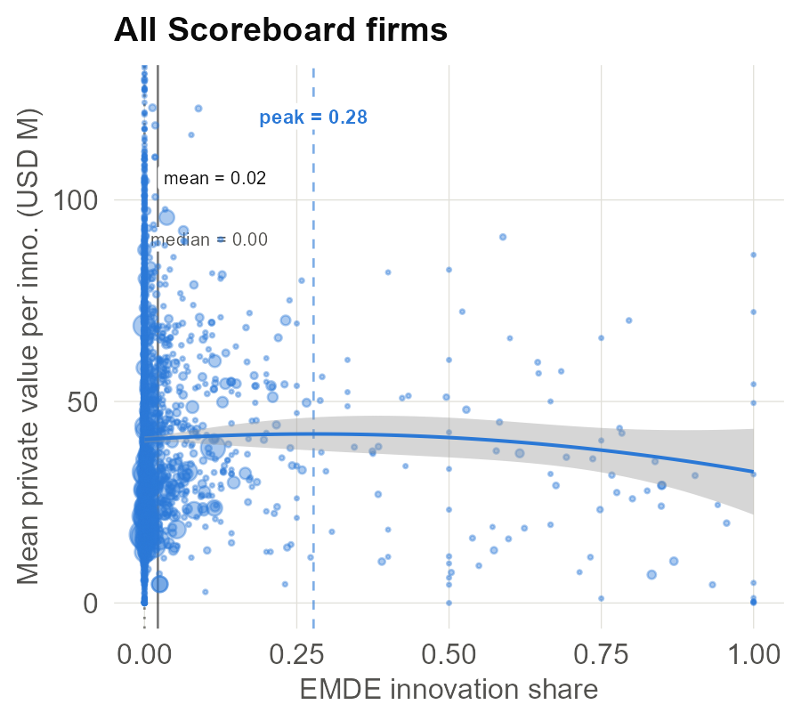

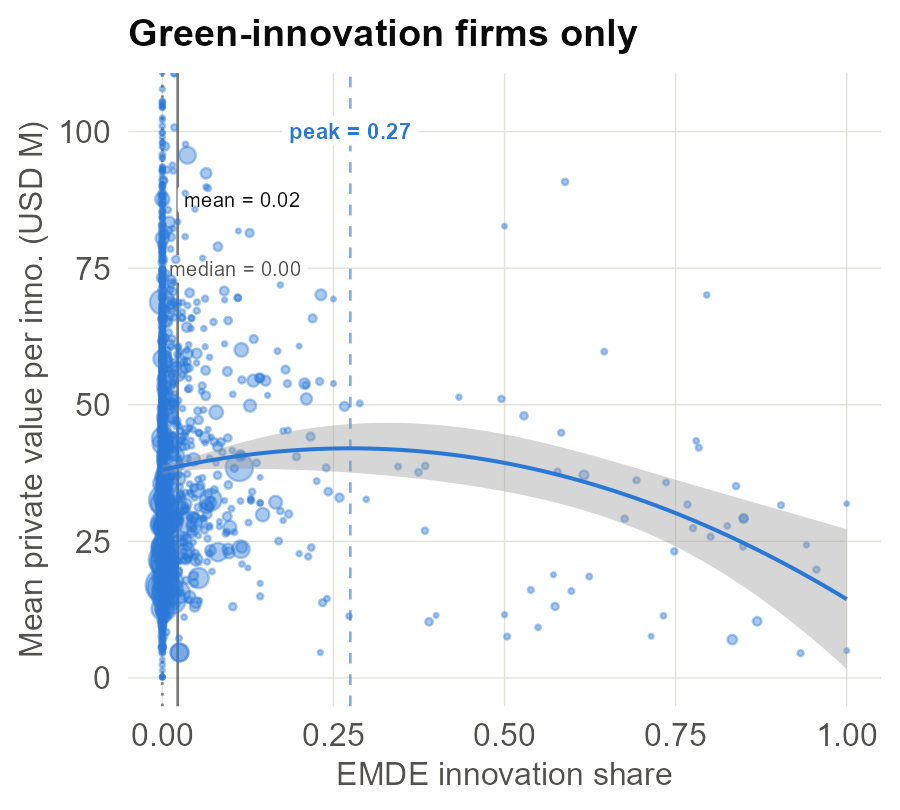

No inverted U for the *private* value of innovations (if anything, slightly decreasing) — the collaboration effect works through knowledge spillovers, not firm profits

## Why an inverted U? A model of knowledge diversity

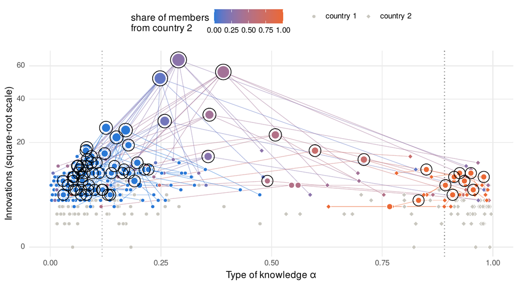

Innovators have a *type* of knowledge α; innovators from different countries cluster by type

Firms are collections of innovators (circles: successful attempts, coloured by the firm’s country-2 share)

Innovation attempts by more type-diverse innovators have a higher success probability

Firms can invest in a foreign lab = a bridge between more diverse knowledge stocks

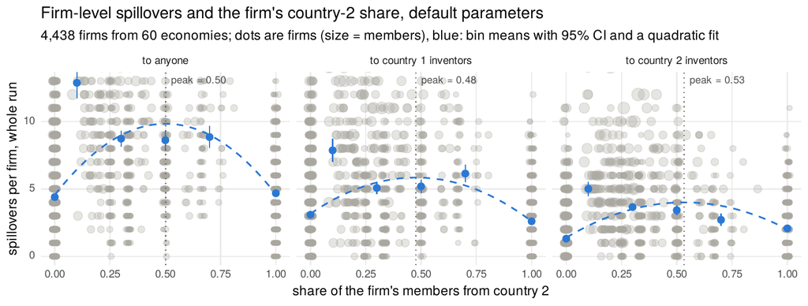

Firm-level spillovers peak at an interior share of country-2 innovators

[figure not shown]

Interactive version, every parameter adjustable:  
mondpanther.github.io/amodel

## EMDE R&D labs as brain pumps?

[figure not shown]

HIC

R&D lab

EMDE

A possible trade-off?

Key variables (LinkedIn career histories of Scoreboard-firm employees):

- Share of employees of firm *i* that move from HIC to EMDE (**brain gain**)
- Share of employees that move from EMDE to HIC (**brain drain**)
- Two ways to count drains and gains:
  - *spell-local*: move around the employment spell at the firm
  - *lifetime*: any such move in the career

$BrainFlow_i = \beta_1\,EMDEShare_i + X_i\gamma + \epsilon_i$

Brain drain or gain?

More drain than gain

|  | Spell-local Gain | Spell-local Drain | Lifetime Gain | Lifetime Drain |
| --- | --- | --- | --- | --- |
| A. OLS, size control = log employees, HQ-country FE |  |  |  |  |
| Developing-country innovation share | 0.0128*** | 0.0176*** | 0.0256*** | 0.0407*** |
|  | (0.0036) | (0.0042) | (0.0060) | (0.0086) |
| Observations | 2,162 | 2,162 | 2,162 | 2,162 |
| R-squared | 0.115 | 0.078 | 0.084 | 0.115 |
| Mean of dep. var. (all matched firms) | 0.021 | 0.033 | 0.056 | 0.085 |

| Sector | Spell-local Gain | Spell-local Drain | Lifetime Gain | Lifetime Drain | N |
| --- | --- | --- | --- | --- | --- |
| Health & Pharma | 0.0095 | 0.0025 | 0.0154 | 0.0230** | 541 |
| ICT Hardware & Electronics | 0.0121* | 0.0121* | 0.0207** | 0.0288** | 440 |
| ICT Software | 0.0234*** | 0.0536*** | 0.0580*** | 0.1011*** | 274 |
| Industrials, Auto & Aero | 0.0128 | 0.0068 | 0.0268 | 0.0268 | 372 |
| Chemicals & Materials | −0.0035 | 0.0271*** | 0.0290* | 0.0733*** | 176 |
| Other | 0.0134** | 0.0099* | 0.0153 | 0.0166 | 357 |

Coefficients on the developing-country (EMDE incl. China) innovation share, HIC-headquartered Scoreboard firms with ≥30 LinkedIn employees; HC1 SEs. *** p<0.01, ** p<0.05, * p<0.1.

Some sectors are more drainy

Moving a firm from no EMDE innovation to all-EMDE innovation raises the lifetime drain share by 4.1 points against a gain of 2.6 points

## EMDERLT – the brain pump tracker

[figure not shown]

[figure not shown]

- Hand-verified R&D lab locations of top R&D firms in EMDE: **≈1,950 lab–country records in 46 host countries** (1,006 from Scoreboard firms, 944 from the patent-holder pipeline)
- Each lab linked to the firm’s innovations mapped to the host country, with average Patent Rank relative to the world average
- Grows daily: automated candidate sweeps, manual verification, commercialisation notes
- mondpanther.github.io/kevceinsights/mnc-rd-labs-map.html

## Faces to the numbers: EMDE spillover champions

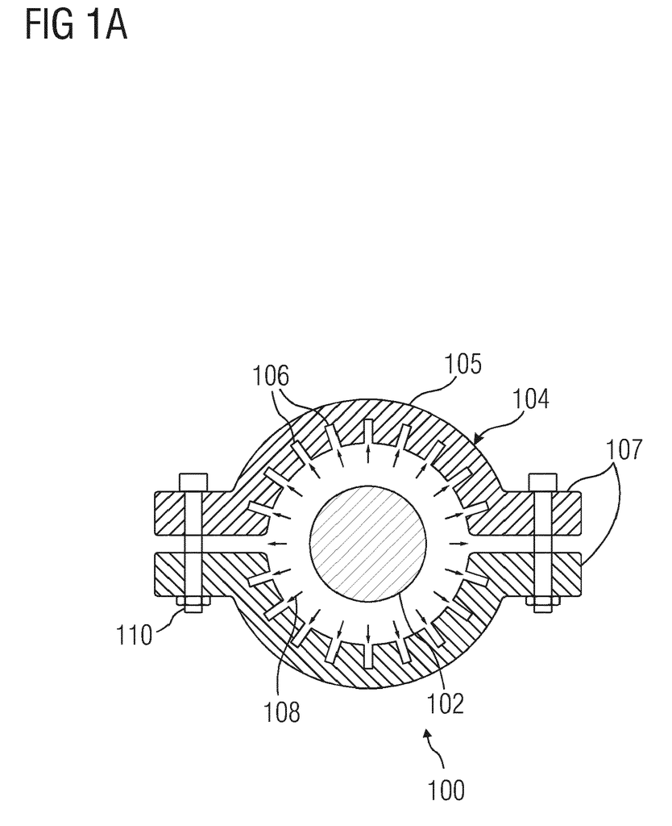

**Siemens** (DE + IN) — steam turbine casing with built-in warming channels

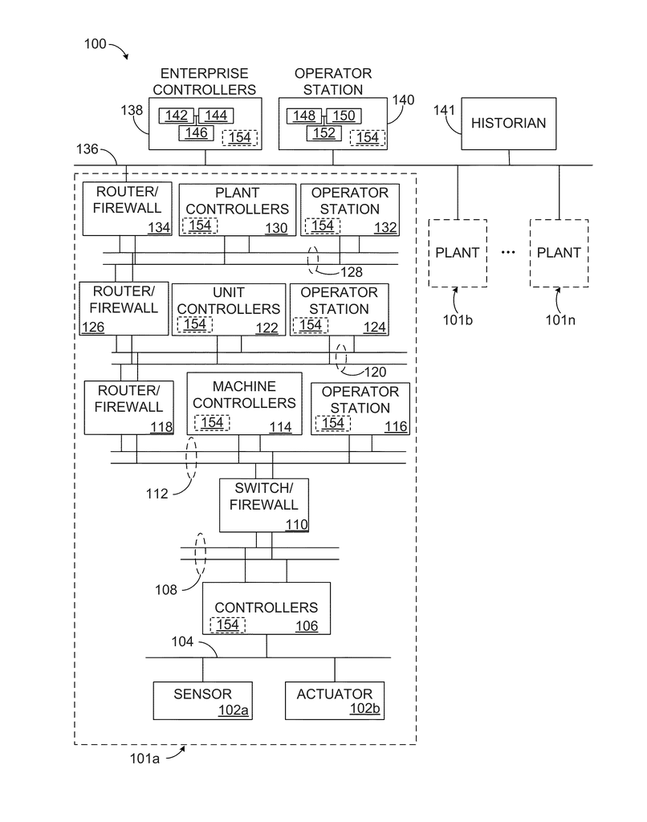

**Honeywell** (US + IN) — upgrading industrial control software without stopping the plant

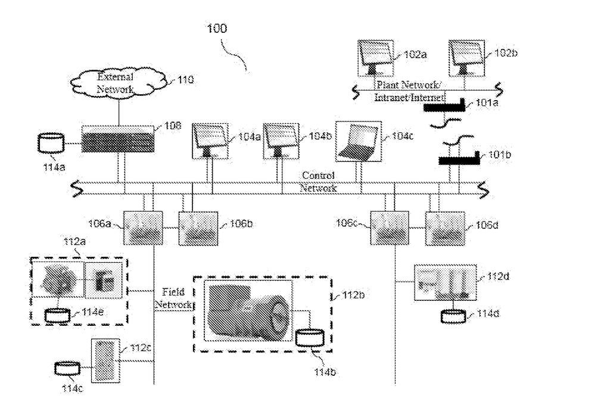

**ABB** (CH + IN) — a single place where plant operators can look up the status and history of any piece of equipment, instead of searching many separate databases

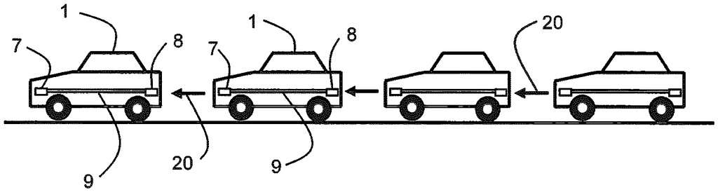

**Vestel Elektronik** (TR + EU) — electric cars charging each other in convoys

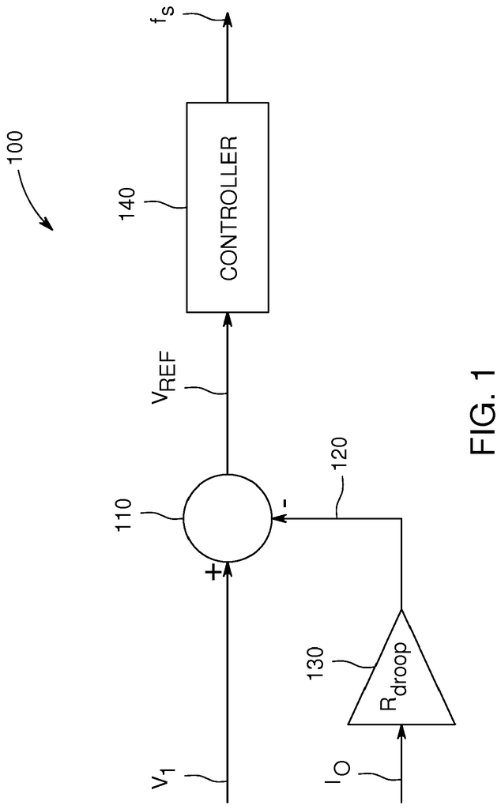

**General Electric** (US + IN + CN + JP) — converting one DC voltage into another with less energy loss, e.g. for solar, battery or data-centre power systems

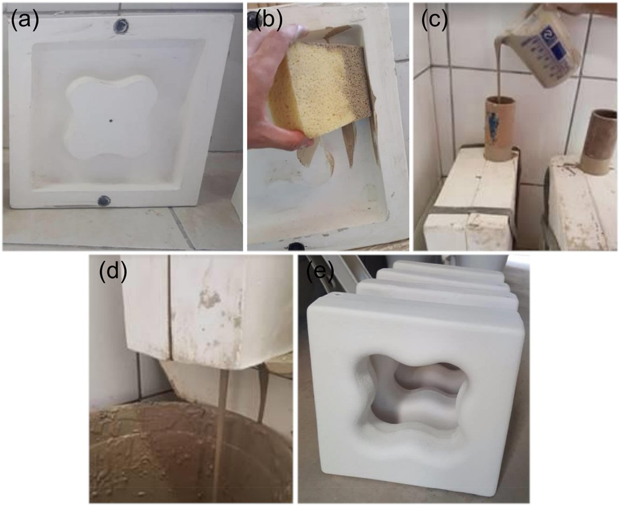

**Braskem** (BR + partners) — ceramic tiles made with chemical-industry brine sludge (illustration: Silva et al. 2022, CC BY)

[figure not shown]

Selection from the **20 Scoreboard firms with the highest average marginal return of spillovers to EMDE** across their green innovations linked to a verified EMDERLT lab (Appendix D of the paper).

Online gallery: [**Link ↗**](https://mondpanther.github.io/kevceinsights/emde-inno-examples.html)

## Conclusion

- Some EMDE innovations are high quality; e.g. green tech
- High-value EMDE innovations are mostly HIC–EMDE collaborations
- **Nearly half** of EMDE innovations involve HIC collaborators — but EMDE inventors appear in only 2% of HIC innovations
- If HIC firms did more in EMDE they would increase spillovers to EMDE
- **And** spillovers to HICs — inverted U peaking at a 37–44% EMDE share; one SD more ≈ +$1.8M to HICs, +$0.5M to EMDE per innovation
- But there might be a net brain drain (especially software; senior staff unaffected)
- HIC R&D subsidies for EMDE investments: a win-win opportunity to mobilise finance for EMDE R&D?

## Going forward

- Dynamic spec? (Do firms become more spilly as they become more collaby?)
- Within-firm variation? (Are collab innos of the same firm more spilly?)
- IV? FDI rule changes? IP law changes? Immigration law?
- Brain flows: career trajectories of returnees and what they bring back

Thanks — r.martin@imperial.ac.uk

The paper

[figure not shown]

[figure not shown]

CEP Discussion Paper No. 2223 · [**Link ↗**](https://cep.lse.ac.uk/pubs/download/dp2223.pdf)

Online tools

[figure not shown]

Innovation Strategy Explorer  
[**Link ↗**](https://tinyurl.com/iseapptata)

[figure not shown]

EMDERLT lab tracker  
[**Link ↗**](https://mondpanther.github.io/kevceinsights/mnc-rd-labs-map.html)

[figure not shown]

Examples gallery  
[**Link ↗**](https://mondpanther.github.io/kevceinsights/emde-inno-examples.html)

IFC report

[figure not shown]

[figure not shown]

*Innovation in Green Technologies*  
[**Link ↗**](https://www.ifc.org/en/insights-reports/2025/innovation-in-green-technologies)

[figure not shown]

## Extra slides

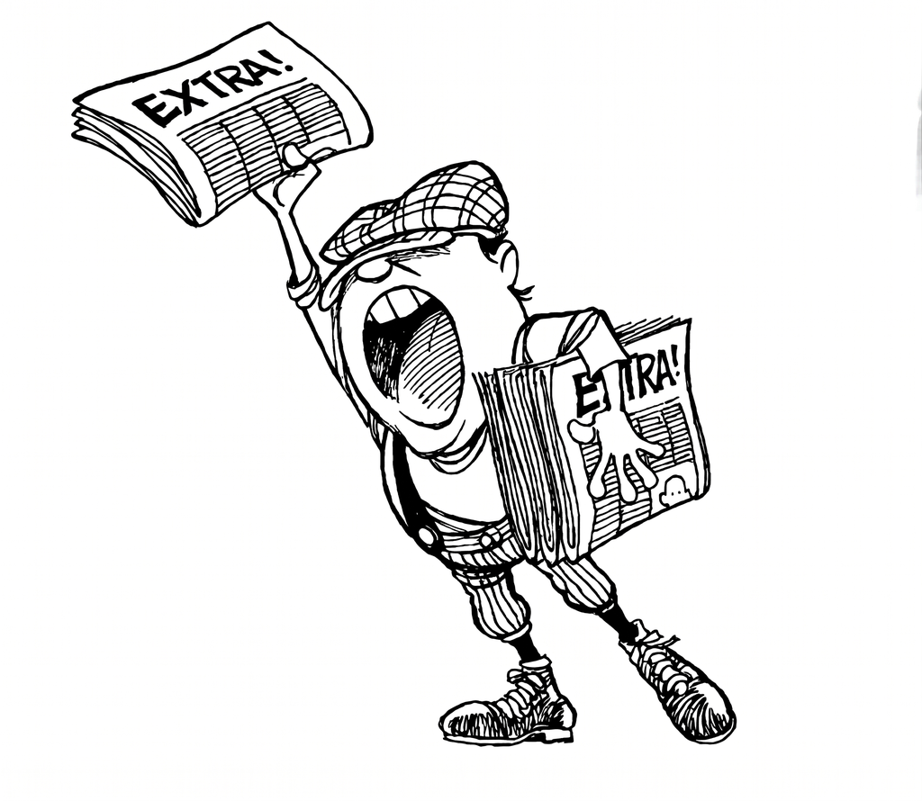

## Binned estimates of the inverted U

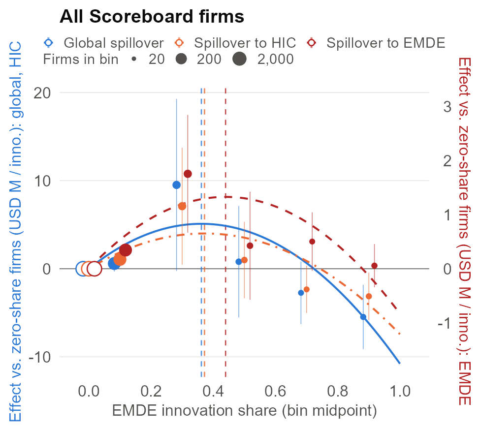

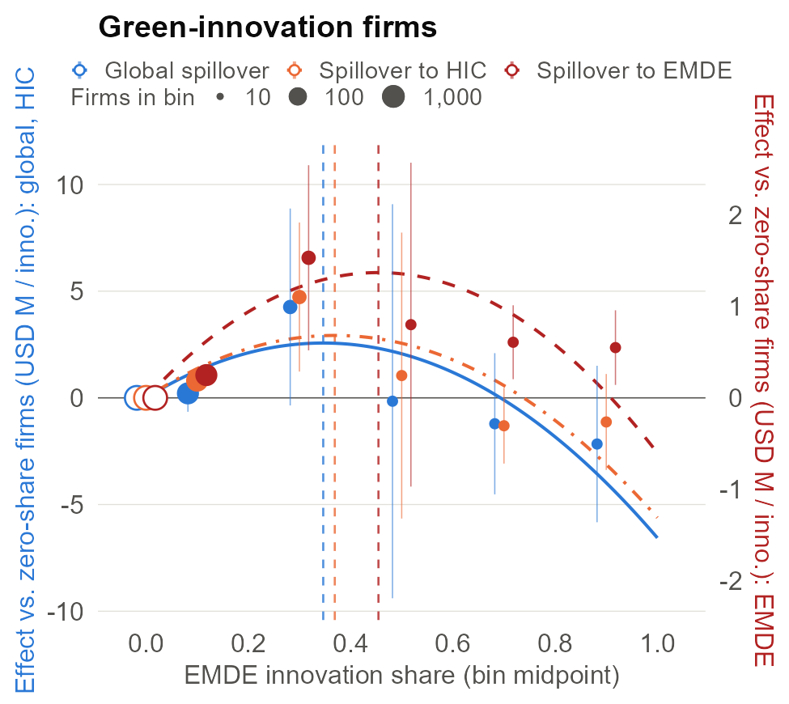

Five equal-width bins, no-collaboration firms as reference: HIC spillover already +$1.1M in the 0–0.2 bin, peak ≈ +$7M at 0.2–0.4, then falls back

## Firm characteristics by EMDE-collaboration group

|  | No collaboration n = 3,303 | Any collaboration n = 983 | Share > 2.2% n = 486 |
| --- | --- | --- | --- |
| EMDE innovation share | 0.000 | 0.096*** | 0.186*** |
| HQ in a high-income country | 0.861 | 0.927*** | 0.886 |
| Innovation portfolio size (100s) | 2.51 | 24.66*** | 11.07*** |
| Number of inventor countries | 3.0 | 13.6*** | 11.8*** |
| R&D per innovation (USD M) | 102.04 | 21.94*** | 35.80*** |
| R&D missing | 0.067 | 0.034*** | 0.039*** |
| Cost of innovation step (USD M) | 11.45 | 12.03*** | 13.18*** |
| Private value (USD M / inno) | 40.82 | 39.78 | 42.04 |

## Brain flows: a closer look (parked)

| EMDE share split | Gain (spell) | Drain (spell) | Gain (life) | Drain (life) |
| --- | --- | --- | --- | --- |
| EMDE excl. China | 0.0123*** | 0.0241*** | 0.0261*** | 0.0398*** |
|  | (0.0044) | (0.0073) | (0.0084) | (0.0129) |
| China | 0.0131** | 0.0126** | 0.0250*** | 0.0409*** |
|  | (0.0055) | (0.0050) | (0.0083) | (0.0113) |
| Observations | 2,162 | 2,162 | 2,162 | 2,162 |

Both shares entered jointly; HQ-country FE, log employees, log inventor countries; HC1 SEs.

- **Net flow is a drain:** net (gain − drain) share falls by 0.30 points*** per unit of EMDE share, driven by employees below senior rank (−0.41***); no significant net effect for senior staff
- Drain is strongest for employees with an **advanced degree** (0.025***)
- **Returnees come back to bigger roles:** HIC→EMDE movers take on average a +0.22 seniority step, EMDE→HIC movers only +0.07
- Non-China EMDE collaboration is the more “drainy” margin at the spell-local horizon

## EMDE spillover champions

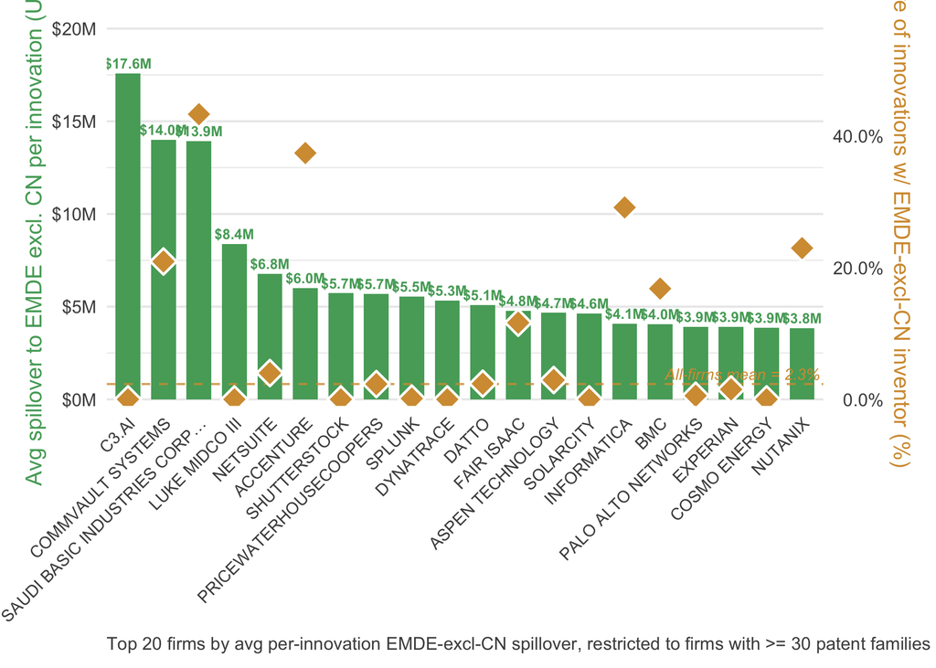

Top-20 firms by average spillover to EMDE (excl. China) per innovation, firms with ≥30 families. An updated, interactive version is the firm gallery of the examples tool.